# Differential Gene Expression Analysis of the PanCK positive (Cancer) cells, LUAD LLM CD4CD14 high vs low

Ilariya, based on CM based on Belinda/Jared code

# 1 Load libraries

```r
library(standR)
library(edgeR)
library(SpatialExperiment)
library(limma)
#library(Glimma)
library(ggrepel)
library(ggalluvial)
library(scater)
library(readxl)
library(tidyverse)
```

```r
library(pheatmap)
library(statmod)
```

# 2 Reproducibility

To ensure reproducibility, a fixed seed is set.

```r
set.seed(42)
```

# 3 Load in Data

```r
# Set the directory and file name
RDataObjectsDir = "../../ilaria/claires_part/rdata/"
speCancerFileName = "speCancerMIBI_GeoMx.rds"

# Read data from file
speCancer <- readRDS(file=file.path(RDataObjectsDir, speCancerFileName))
```

# 4 Analysis-Specific Filtering

Only the LUAD cancer will be analysed for relapse free survival:

```r
head(speCancer$CancerType)
```

```
## [1] "LUAD" "LUAD" "LUAD" "LUAD" "LUAD" "LUAD"
```

```r
keep <- speCancer$CancerType == "LUAD"
table(keep)
```

```
## keep
## FALSE  TRUE
##    56   122
```

```r
speCancer <- speCancer[,keep]
```

NEW: update immune subgroups

```r
CM_LUAD_immune_subgroups <- readRDS("~/cd14_paper/data/CM_LUAD_immune_subgroups.rds")
table(CM_LUAD_immune_subgroups$cluster)
```

```
##
##  L LM  M
## 19 16  9
```

```r
speCancer$ImmuneSubgr <- CM_LUAD_immune_subgroups$cluster[match(speCancer$SampleName, CM_LUAD_immune_subgroups$patient)]
```

```r
head(speCancer$ImmuneSubgr)
```

```
## [1] L  LM LM LM LM M
## Levels: L LM M
```

```r
keep <- speCancer$ImmuneSubgr != "M"
table(keep)
```

```
## keep
## FALSE  TRUE
##    38    84
```

```r
speCancer <- speCancer[,keep]
```

New: update CD4CD14 infiltration

```r
CM_cohort_Tumour_LLM_CD4CD14 <- readRDS("~/cd14_paper/data/Percentage_CM_cohort_Tumour_LLM_CD4CD14.rds")
speCancer$CD4CD14_high <- CM_cohort_Tumour_LLM_CD4CD14$CD4CD14_high[match(speCancer$SampleName,
                                                                               CM_cohort_Tumour_LLM_CD4CD14$Patient)]

speCancer$PercentageCD4CD14 <- CM_cohort_Tumour_LLM_CD4CD14$PercentageCD4CD14[match(speCancer$SampleName,
                                                                               CM_cohort_Tumour_LLM_CD4CD14$Patient)]
```

There is missing data on CD4CD14 infiltration. Filter out any samples with missing information

```r
table(speCancer$CD4CD14_high)
```

```
##
## FALSE  TRUE
##    14     8
```

```r
table(is.na(speCancer$CD4CD14_high))
```

```
##
## FALSE  TRUE
##    22    62
```

```r
keep <- !is.na(speCancer$CD4CD14_high)
speCancer <- speCancer[,keep]
# look at old vs new. why did we lost so much?
table(speCancer$CD4CD14, speCancer$CD4CD14_high)
```

```
##
##        FALSE TRUE
##   high     9    8
##   low      2    0
```

```r
#which patients did we lost?
unique(speCancer$SampleName[speCancer$CD4CD14 == "high" & speCancer$CD4CD14_high == F])
```

```
## [1] "12MH0925" "12SH0270" "13PM0638" NA
```

```r
speCancer$CD4CD14_old <- speCancer$CD4CD14
speCancer$CD4CD14 <- ifelse(speCancer$CD4CD14_high, "high", "low")
```

## 4.1 Comparisons

Starting with Sex: more male with high than female

```r
table(colData(speCancer)$CD4CD14, colData(speCancer)$Sex)
```

```
##
##        Female Male
##   high      1    7
##   low       3   11
```

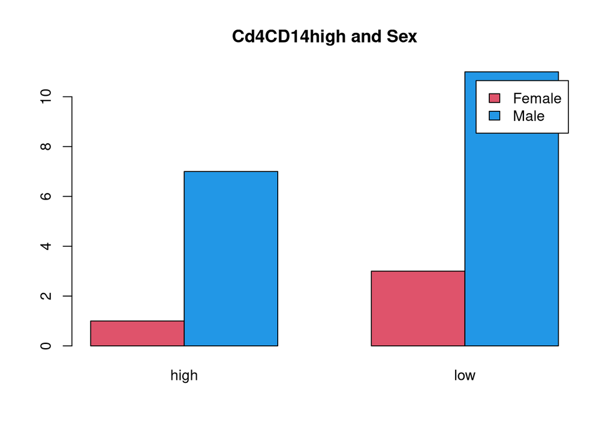

```r
barplot(table(colData(speCancer)$Sex, colData(speCancer)$CD4CD14), beside = TRUE, legend = TRUE, col = c(2 ,4), main = "Cd4CD14high and Sex")
```

Running a test of independence shows that the p-value is not significant

```r
summary(table(colData(speCancer)$CD4CD14, colData(speCancer)$Sex))
```

```
## Number of cases in table: 22
## Number of factors: 2
## Test for independence of all factors:
##  Chisq = 0.27282, df = 1, p-value = 0.6014
##  Chi-squared approximation may be incorrect
```

look at age

younger people with CD4CD14high infiltration

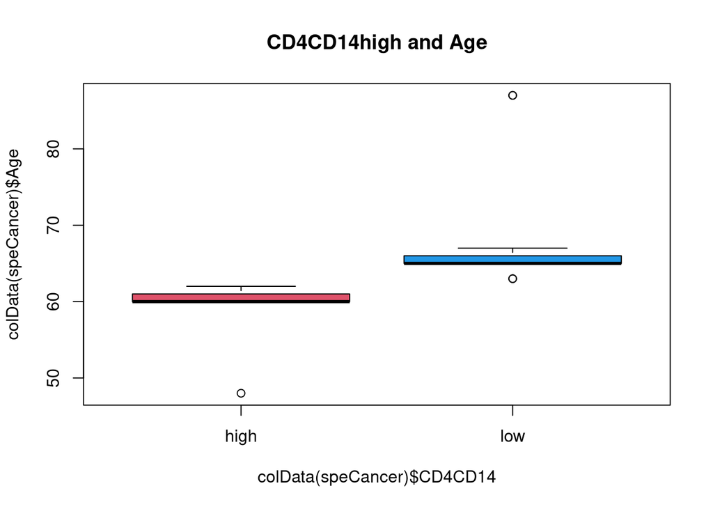

```r
boxplot(colData(speCancer)$Age ~ colData(speCancer)$CD4CD14, col = c(2 ,4), main = "CD4CD14high and Age")
```

```r
summary(lm(colData(speCancer)$Age ~ colData(speCancer)$CD4CD14))
```

```
##
## Call:
## lm(formula = colData(speCancer)$Age ~ colData(speCancer)$CD4CD14)
##
## Residuals:
##     Min      1Q  Median      3Q     Max
## -11.000  -3.143  -2.143   1.000  18.857
##
## Coefficients:
##                               Estimate Std. Error t value Pr(>|t|)
## (Intercept)                     59.000      2.485  23.746 3.98e-16 ***
## colData(speCancer)$CD4CD14low    9.143      3.115   2.935  0.00818 **
## ---
## Signif. codes:  0 '***' 0.001 '**' 0.01 '*' 0.05 '.' 0.1 ' ' 1
##
## Residual standard error: 7.027 on 20 degrees of freedom
## Multiple R-squared:  0.3011, Adjusted R-squared:  0.2662
## F-statistic: 8.617 on 1 and 20 DF,  p-value: 0.008179
```

Next, we shall look at Smoking Status.

```r
table(colData(speCancer)$CD4CD14, colData(speCancer)$SmokingStatus)
```

```
##
##        ES not cited
##   high  0         8
##   low   7         7
```

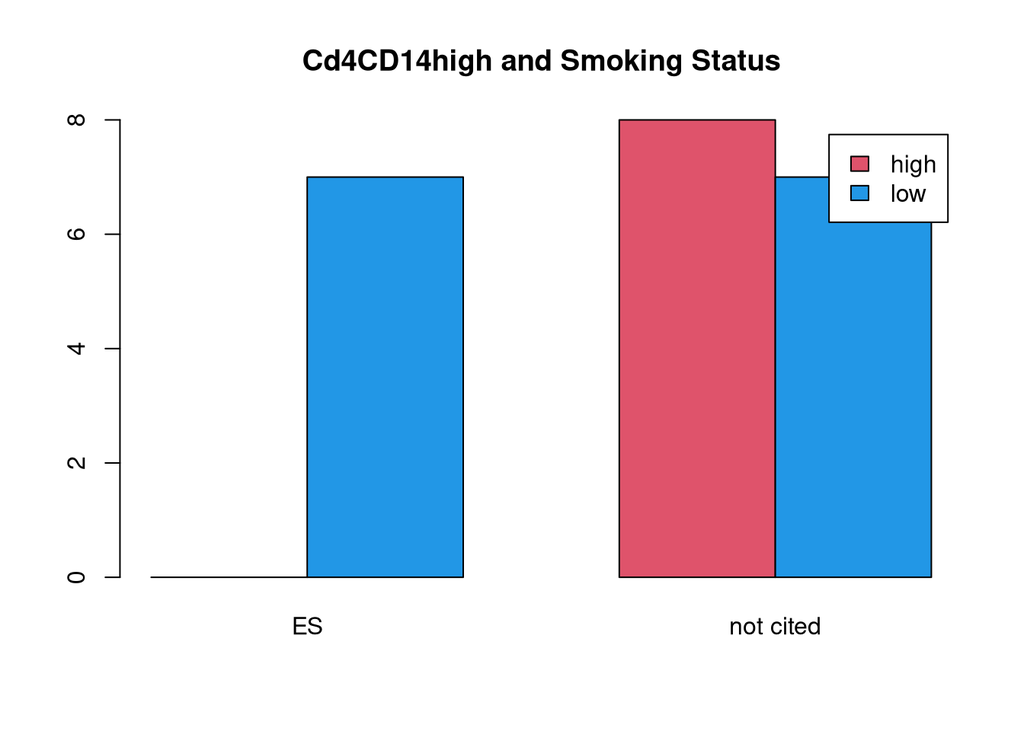

```r
barplot(table(colData(speCancer)$CD4CD14, colData(speCancer)$SmokingStatus), beside = TRUE, legend = TRUE, col = c(2 ,4), main = "Cd4CD14high and Smoking Status")
```

# 5 TMM normalization

The next step is to undergo normalisation. TMM is used in the analysis

Normalise using the standR function `geomxNorm`

```r
spe_tmm_cancer <- geomxNorm(speCancer, method = "TMM")
```

Convert to DGE object for Differential Gene Expression Analysis

```r
dgeCancer <- SE2DGEList(spe_tmm_cancer)
```

Copy over the norm factors manually as the norm.factors are not copied over by default

```r
dgeCancer$samples$norm.factors <- metadata(spe_tmm_cancer)$norm.factor

dgeCancer$samples$group <- as.factor(dgeCancer$samples$CD4CD14)

dgeCancer$samples <- dgeCancer$samples[, c("group", "lib.size", "norm.factors", "SampleName", "Age", "Sex",
                                           "SmokingStatus", "ImmuneSubgr", "CD4CD14", "CD4CD14_old",
                                           "KRASmut", "EGFR", "TotImmuneInf", "CNV", "PercentageCD4CD14")]
```

Visualize the counts to ensure that normalisation worked properly.

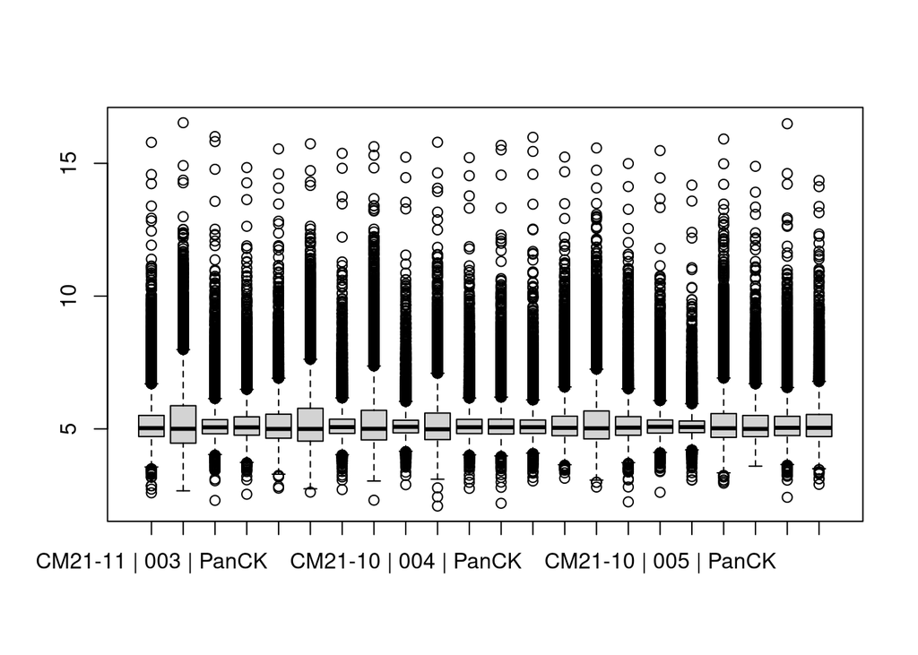

```r
logcountsCancer <- cpm.DGEList(dgeCancer, log=TRUE)
boxplot(logcountsCancer)
```

View the RLE plot as well to ensure the samples are good.

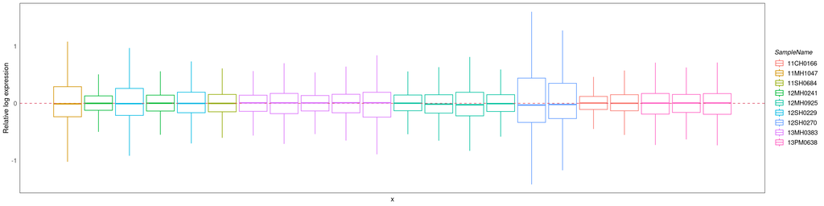

```r
plotRLExpr(spe_tmm_cancer, ordannots = "SlideName", assay = "logcounts", col = SampleName)
```

# 6 DGE Analysis

To make sure that we are looking at high-low, set order of levels in factor

```r
#dgeCancer$samples$CD4CD14[is.na(dgeCancer$samples$CD4CD14)] <- "non_relevant"

cd14_status <- factor(dgeCancer$samples$CD4CD14, levels = c("low", "high"))
age <- dgeCancer$samples$Age
smoking_stat <- factor(dgeCancer$samples$SmokingStatus)

designCancer <- model.matrix(~ cd14_status + age + smoking_stat)
head(designCancer)
```

```
##   (Intercept) cd14_statushigh age smoking_statnot cited
## 1           1               0  65                     1
## 2           1               0  66                     0
## 3           1               0  65                     1
## 4           1               0  87                     0
## 5           1               0  65                     1
## 6           1               0  66                     0
```

with normalisation

```
## First intra-block correlation  0.6176783
```

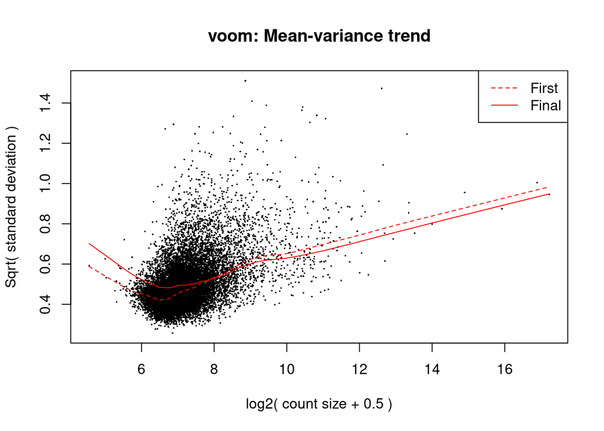

```
## Final intra-block correlation  0.6110778
```

```r
par(mfrow=c(1,1))
vCancer <- voomLmFit(dgeCancer, designCancer, plot = TRUE, span = 0.05,
                     block = dgeCancer$samples$SampleName,
                     normalize.method="cyclicloess")
```

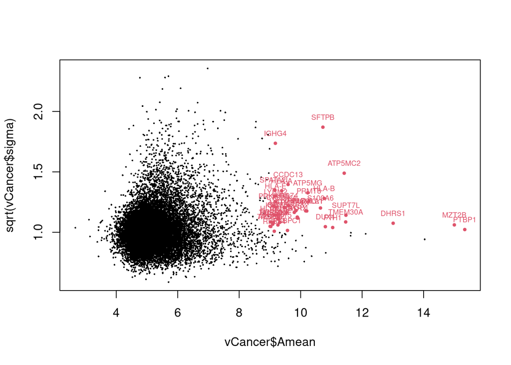

```r
HVs <- vCancer[which(vCancer$Amean > 9 & vCancer$sigma > 1), ]

plot(vCancer$Amean, sqrt(vCancer$sigma), pch=16, cex=0.3)

points(HVs$Amean, sqrt(HVs$sigma),
       pch = 19, col = 2, cex = 0.5)
text(HVs$Amean, sqrt(HVs$sigma),
     labels = rownames(HVs$genes),
     pos = 3, cex = 0.6, col = 2)
```

```r
fitCancer <- eBayes(vCancer, robust = TRUE)
```

```r
dim(fitCancer)
```

```
## [1] 18676     4
```

```r
summa.fitCancer <- decideTests(fitCancer)
summary(summa.fitCancer)
```

```
##        (Intercept) cd14_statushigh   age smoking_statnot cited
## Down             0               2    45                   132
## NotSig         213           18674 18616                 18494
## Up           18463               0    15                    50
```

```r
topResultCancer <- topTable(fitCancer, coef = 2, sort.by = "p", n = Inf)
topGenesCancer <- topTable(fitCancer, coef = 2, sort.by = "p", n = Inf, p.value = 0.05)
```

Remove columns as some are not of interest in this analysis

```r
topResultCancer <- subset(topResultCancer, select = c(GeneID, logFC, AveExpr, t, P.Value, adj.P.Val, B))
topGenesCancer <- subset(topGenesCancer, select = c(GeneID, logFC, AveExpr, t, P.Value, adj.P.Val, B))
```

# 7 GSEA

The first approach is to take genes that are p.value & LFC acceptable (note: not adjusted as we have only 2 true DE with FDR < 0.05). Second approach is using camera test (which is much better in our case)

## 7.1 GO and KEGG

```r
topResultsnonadjPval <- topResultCancer[topResultCancer$P.Value < 0.05,]
topResultsnonadjPvalandLFC <- topResultsnonadjPval[topResultsnonadjPval$logFC > 0.5, ]

all.ids <- topResultCancer$GeneID[!is.na(topResultCancer$GeneID)]
ids <- topResultsnonadjPvalandLFC$GeneID
# topResultsnonadjPval
ids <- topResultsnonadjPval$GeneID
signif.ids <- topGenesCancer$GeneID[!is.na(topGenesCancer$GeneID)]

kegg = kegga(ids, species = "Hs", universe = all.ids)
top.KEGG <- topKEGG(kegg, p.value = 0.05, number = 50)
head(top.KEGG, n=20)
write.csv(top.KEGG, file = "KEGG.res.PosLFC_high_inCD14_high.csv")

go = goana(ids, species = "Hs", universe = all.ids)
top.GO.BP <- topGO(go, ontology = "BP", number =100, p.value = 0.05)
top.GO <- topGO(go, number =100, p.value = 0.05)
head(top.GO, n=20)

write.csv(top.GO.BP, file = "GO.res.PosLFC_high_inCD14_high.csv")
```

[output not shown]

```r
plot_GO_res <- function(top_go, n, direct, comp_name){
  top_go <- top_go[1:n, c(1:3, which(endsWith(colnames(top_go), direct)))]
  colnames(top_go) <- gsub(paste0("P.",direct),"P.val",colnames(top_go))
  top_go$Prop <- top_go[[direct]]/top_go$N
  top_go <- top_go[order(-top_go$P.val), ]
  top_go$Term <- factor(top_go$Term, levels = top_go$Term)
  top_go$Ont <- as.factor(top_go$Ont)

p <- ggplot(top_go, aes(x = Term, y = log10(P.val), size = Prop)) +
  geom_point(stat = "identity", aes(colour = Ont)) +
  ggtitle(paste0("Gene Ontology Top ",n, "\n",direct)) +
  labs(size = paste0("Prop of Term ", direct), col = "Ontology") +
  scale_colour_manual(values = c("#FF9DA7", "#4E79A7", "#59A14F")) +
  ylab("Log10 of pValue") + theme_minimal() + coord_flip()
ggsave(paste0("output/plots/GO", "_",direct,"_",comp_name,".png"),
       plot = p, width = 9, height = 7, units = "in", bg = "white")
return(p)
}
```

```r
plot_GO_res(top.GO.BP, n=20, direct = "DE", comp_name = "cd14_high")
```

[output not shown]

```r
plot_KEGG_res <- function(top_kegg, n, direct, comp_name){
  top_kegg <- top_kegg[1:n,]
  colnames(top_kegg) <- gsub(paste0("P.",direct),"P.val",colnames(top_kegg))
  top_kegg$Prop <- top_kegg[[direct]]/top_kegg$N
  top_kegg <- top_kegg[order(-top_kegg$P.val), ]
  top_kegg$Pathway <- factor(top_kegg$Pathway, levels = top_kegg$Pathway)

p <- ggplot(top_kegg, aes(x = Pathway, y = log10(P.val), size = Prop)) +
  geom_point(stat = "identity", aes(colour = N)) +
  ggtitle(paste0("KEGG Top ",n, "\n",direct, " in ",comp_name)) +
  labs(size = paste0("Prop of path ", direct), col = "Path size") +
  ylab("Log10 of pValue") + theme_minimal() + coord_flip()
ggsave(paste0("output/plots/kegg_",comp_name, ".png"),
       plot = p, width = 9, height = 7, units = "in", bg = "white")
return(p)
}
```

```r
plot_KEGG_res(top.KEGG, n=30, direct="DE", comp_name = "cd14_high")
```

[output not shown]

## 7.2 Using `camera` for GSEA

Belinda suggested to use `camera`

### 7.2.1 KEGG

```r
Hs.KEGG <- readRDS("data/Hs.c2.cp.kegg.v7.1.entrez.rds")
ind <- ids2indices(Hs.KEGG, dgeCancer$genes$GeneID)
test <- camera(vCancer$EList$E, index=ind, design = vCancer$design,
               contrast="cd14_statushigh", weights = vCancer$EList$weights)
write.csv(test[test$FDR < 0.05,], file = "output/csv/cancerLUADLLMCD4CD14_KEGG.csv")
```

### 7.2.2 Reactome

```r
Hs.reactome <- readRDS("data/Hs.c2.cp.reactome.v7.1.entrez.rds")
ind <- ids2indices(Hs.reactome, dgeCancer$genes$GeneID)
test <- camera(vCancer$EList$E, index=ind, design = designCancer, contrast="cd14_statushigh")
write.csv(test[test$FDR < 0.05,], file = "output/csv/cancerLUADLLMCD4CD14_reactome_cd14_high.csv")
```

### 7.2.3 Functions

```r
run.camera.with.db <- function(vCancer, db, contrast){
  ind <- ids2indices(db, vCancer$genes$GeneID)
  test <- camera(vCancer$EList$E, index=ind, design = vCancer$design,
               contrast=contrast, weights = vCancer$EList$weights)
  res <- list(index = ind, test = test)
  res
}

get.genes.from.pathways.with.name <- function(camera.results, name, de.results, vCancer, fitCancer, contrast){
  camera.test.res <- camera.results$test
  ind <- camera.results$index
  subset.of.interest <- camera.test.res[grepl(name, rownames(camera.test.res), ignore.case = T),]
  r.go <- rownames(subset.of.interest)

  wb <- createWorkbook()
  addWorksheet(wb = wb, sheetName = paste0("list_with_",name))
  writeData(wb = wb, sheet = 1, x = subset.of.interest, rowNames = T)

  for (i in 1:length(r.go)) {

    # get list of genes and write in
      gene.list.from.go <- vCancer$genes[ind[[r.go[i]]],]
      res.sub.table <- de.results[match(gene.list.from.go$GeneID, de.results$GeneID),
                                    c("logFC", "t", "AveExpr", "adj.P.Val")]
      gene.list.from.go <- cbind(gene.list.from.go, res.sub.table)
      #sheet.name <- paste0(substr(r.go[i], 1, 9),"_",substr(r.go[i], str_length(r.go[i])-20, str_length(r.go[i])))
      sheet.name <- paste0(substr(r.go[i], 1, 30), i)
      addWorksheet(wb = wb, sheetName = sheet.name)
      writeData(wb = wb, sheet = i+1, x = gene.list.from.go, rowNames = T)

      # get a barcode plot and save it as pdf
      #path.dir.pdf <- "./output/pdf/"
      #pdf(file = paste0(path.dir.pdf,"barcode_", r.go[i], ".pdf"),
        #  width=8, height=5)
      p <- barcodeplot(fitCancer$t[,contrast], index = ind[[r.go[i]]], main = r.go[i])
      print(p)
      #dev.off()
  }

  #path.to.csv <- "./output/csv/"
  #saveWorkbook(wb, paste0(path.to.csv,"Paths_with_",name,"_in_name.xlsx"), overwrite = TRUE)
}
```

### 7.2.4 Hallmark

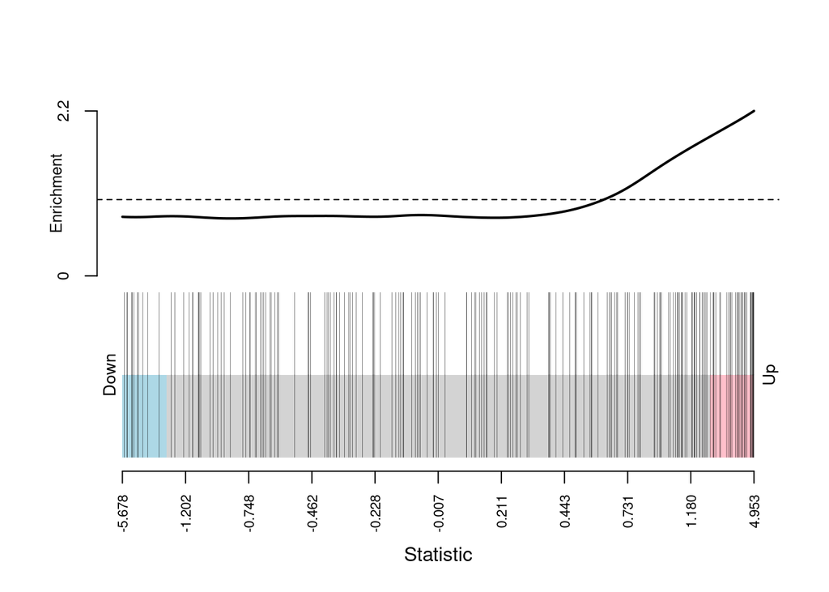

```r
# contrast "cd14levelhigh"

#Hs.GO.BP <- readRDS("data/Hs.c5.bp.v7.1.entrez.rds")
#Hs.reactome <- readRDS("data/Hs.c2.cp.reactome.v7.1.entrez.rds")
hallmark.db <- readRDS("../../ilaria/spe_sorin/data/Hs.h.all.v7.1.entrez.rds")
#GO.res <- run.camera.with.db(vCancer = vCancer, db = Hs.GO.BP)
#reactome.res <- run.camera.with.db(vCancer = vCancer, db = Hs.reactome)
#kegg.res <- run.camera.with.db(vCancer = vCancer, db = Hs.KEGG)
hallmark.res <- run.camera.with.db(vCancer = vCancer, db = hallmark.db, contrast = "cd14_statushigh")

barcodeplot(fitCancer$t[,2], index = hallmark.res$index$HALLMARK_TNFA_SIGNALING_VIA_NFKB)
```

```r
#get.genes.from.pathways.with.name(GO.res, "MHC_CLASS_I", de.results = topResultCancerCD4, vCancer, #fitCancer)
#get.genes.from.pathways.with.name(kegg.res, "CYTOKINE_CYTOKINE", de.results = topResultCancerCD4, vCancer, #fitCancer)
#get.genes.from.pathways.with.name(kegg.res, "NATURAL_KILLER", de.results = topResultCancerCD4, vCancer, #fitCancer)
#get.genes.from.pathways.with.name(kegg.res, "OXIDATIVE_PHOSPH", de.results = topResultCancerCD4, vCancer, #fitCancer)
#get.genes.from.pathways.with.name(reactome.res, "OXIDATIVE_PHOSPH", de.results = topResultCancerCD4, #vCancer, fitCancer)
#
#get.genes.from.pathways.with.name(hallmark.res, "TNFA_SIGNALING", de.results = topResultCancer,
#                                  vCancer, fitCancer, contrast = "cd14_statushigh")
#
#write.csv(hallmark.res$test[hallmark.res$test$FDR < 0.05,], file = #"output/csv/GSEA_hallmark_cd14_high.csv")
```

```r
roast(vCancer$EList$E, design = vCancer$design, contrast = "cd14_statushigh",
      index = hallmark.res$index$HALLMARK_TNFA_SIGNALING_VIA_NFKB)
```

```
##          Active.Prop    P.Value
## Down       0.1313131 0.94123531
## Up         0.3080808 0.05901475
## UpOrDown   0.3080808 0.11800000
## Mixed      0.4393939 0.00500000
```

```r
# mixed 0.0075
# Up 0.063
```